# SI 618 - Homework #1: Data Manipulation

Version 2023.09.06.01.CT (Fall 2023)

## Background

This homework assignment focuses on the analysis of biometric data and exercise performance.

Your main task in this assignment is to explore the data *using the data manipulation methods we covered in class*, as well as those in the assigned readings and video resources. You may need to consult pandas documentation, Stack Overflow, Copilot, or other online resources.

A total of 100 points is available in this homework assignment, broken down as shown beside each question and in the accompanying rubric in Canvas. Please note that to receive full points, code should conform to [PEP 8](https://www.python.org/dev/peps/pep-0008/) guidelines, and written responses should be grammatically correct, free of spelling errors, and generally follow the [Strunk & White](https://drive.google.com/file/d/1L0P7xJwjUGBvyb49mL3dw1Bt7hzRTiTl/view) guidelines. You should review those guidelines before proceding with the assignment.

## Download the data from:

https://www.kaggle.com/kukuroo3/body-performance-data

```python
MY_UNIQNAME = 'yanlunar' # please fill in your uniqname
```

## Answer the following questions.

Points for each question are shown below.

For each question, you should

1. Write code using Python and pandas that can help you answer the following questions, and
2. Explain your answers in plain English. You should use complete sentences that would be understood by an educated professional who is not necessarily a data scientist (like a product manager). When we ask for an explanation of your answer, we are interested in your interpretation of the analyses that you produce. With the exception of Question 1a, we are not interested in a description of the steps you took to arrive at your answer.

### Q1: 8 pt(total):

#### Q1b (5pt): Write and execute the code that will do the steps you identified in Part (a) of this question.

```python
# import libraries
import pandas as pd

# read in the data
df = pd.read_csv('bodyPerformance.csv')

# describe the dataset
print("The size of the dataset is:", df.shape)
print("The number of rows of the dataset is:", len(df))
print("The number of columns of the dataset is:", len(df.columns))
```

```
The size of the dataset is: (13393, 12)
The number of rows of the dataset is: 13393
The number of columns of the dataset is: 12
```

```python
# print the first 5 rows of the dataset
df.head(5)
```

|  | age | gender | height_cm | weight_kg | body fat_% | diastolic | systolic | gripForce | sit and bend forward_cm | sit-ups counts | broad jump_cm | class |
| --- | --- | --- | --- | --- | --- | --- | --- | --- | --- | --- | --- | --- |
| 0 | 27.0 | M | 172.3 | 75.24 | 21.3 | 80.0 | 130.0 | 54.9 | 18.4 | 60.0 | 217.0 | C |
| 1 | 25.0 | M | 165.0 | 55.80 | 15.7 | 77.0 | 126.0 | 36.4 | 16.3 | 53.0 | 229.0 | A |
| 2 | 31.0 | M | 179.6 | 78.00 | 20.1 | 92.0 | 152.0 | 44.8 | 12.0 | 49.0 | 181.0 | C |
| 3 | 32.0 | M | 174.5 | 71.10 | 18.4 | 76.0 | 147.0 | 41.4 | 15.2 | 53.0 | 219.0 | B |
| 4 | 28.0 | M | 173.8 | 67.70 | 17.1 | 70.0 | 127.0 | 43.5 | 27.1 | 45.0 | 217.0 | B |

```python
df.describe().round(1)
```

|  | age | height_cm | weight_kg | body fat_% | diastolic | systolic | gripForce | sit and bend forward_cm | sit-ups counts | broad jump_cm |
| --- | --- | --- | --- | --- | --- | --- | --- | --- | --- | --- |
| count | 13393.0 | 13393.0 | 13393.0 | 13393.0 | 13393.0 | 13393.0 | 13393.0 | 13393.0 | 13393.0 | 13393.0 |
| mean | 36.8 | 168.6 | 67.4 | 23.2 | 78.8 | 130.2 | 37.0 | 15.2 | 39.8 | 190.1 |
| std | 13.6 | 8.4 | 11.9 | 7.3 | 10.7 | 14.7 | 10.6 | 8.5 | 14.3 | 39.9 |
| min | 21.0 | 125.0 | 26.3 | 3.0 | 0.0 | 0.0 | 0.0 | -25.0 | 0.0 | 0.0 |
| 25% | 25.0 | 162.4 | 58.2 | 18.0 | 71.0 | 120.0 | 27.5 | 10.9 | 30.0 | 162.0 |
| 50% | 32.0 | 169.2 | 67.4 | 22.8 | 79.0 | 130.0 | 37.9 | 16.2 | 41.0 | 193.0 |
| 75% | 48.0 | 174.8 | 75.3 | 28.0 | 86.0 | 141.0 | 45.2 | 20.7 | 50.0 | 221.0 |
| max | 64.0 | 193.8 | 138.1 | 78.4 | 156.2 | 201.0 | 70.5 | 213.0 | 80.0 | 303.0 |

### Q2: 5 pt:

Without using pd.DataFrame.describe(), report the median age, height, and weight for people in the data. Round your answer to the nearest whole number. Be sure to indicate units for each variable in your write-up.

```python
print("median age: ", int(df['age'].median().round()), "years old")
print("median height: ", int(df['height_cm'].median().round()), "cm")
print("median weight: ", int(df['weight_kg'].median().round()), "kg")
```

```
median age:  32 years old
median height:  169 cm
median weight:  67 kg
```

### Q3: 5 pt:

Look for any anomalous data points. For example, are there cases where diastolic blood pressure is higher than systolic blood pressure (which is physiologically impossible)? Do you notice any other anomalies?

```python
df[df['diastolic'] > df['systolic']]
```

|  | age | gender | height_cm | weight_kg | body fat_% | diastolic | systolic | gripForce | sit and bend forward_cm | sit-ups counts | broad jump_cm | class |
| --- | --- | --- | --- | --- | --- | --- | --- | --- | --- | --- | --- | --- |
| 7495 | 30.0 | F | 156.2 | 52.80 | 28.2 | 156.2 | 104.0 | 21.7 | 27.2 | 43.0 | 162.0 | C |
| 7597 | 30.0 | M | 166.6 | 66.08 | 14.4 | 67.0 | 14.0 | 53.8 | 17.2 | 57.0 | 221.0 | A |
| 8217 | 31.0 | M | 176.7 | 80.32 | 20.8 | 46.2 | 43.9 | 43.9 | 17.2 | 57.0 | 221.0 | B |
| 12949 | 24.0 | M | 171.0 | 78.70 | 20.0 | 99.0 | 95.0 | 46.5 | 12.8 | 50.0 | 197.0 | D |

```python
df.sort_values('diastolic').head(10)
```

|  | age | gender | height_cm | weight_kg | body fat_% | diastolic | systolic | gripForce | sit and bend forward_cm | sit-ups counts | broad jump_cm | class |
| --- | --- | --- | --- | --- | --- | --- | --- | --- | --- | --- | --- | --- |
| 10624 | 26.0 | F | 160.0 | 63.56 | 32.0 | 0.0 | 0.0 | 23.7 | 17.1 | 23.0 | 128.0 | D |
| 3524 | 44.0 | M | 177.0 | 78.28 | 22.1 | 6.0 | 145.0 | 47.4 | 10.5 | 42.0 | 215.0 | B |
| 336 | 35.0 | M | 173.1 | 77.60 | 22.8 | 8.0 | 122.0 | 46.4 | 16.7 | 47.0 | 216.0 | B |
| 6786 | 22.0 | F | 164.1 | 60.80 | 32.4 | 30.0 | 122.0 | 29.7 | -4.6 | 31.0 | 159.0 | D |
| 344 | 22.0 | F | 158.5 | 49.30 | 27.0 | 37.0 | 77.0 | 27.1 | 21.0 | 59.0 | 178.0 | B |
| 6234 | 59.0 | F | 152.1 | 50.60 | 35.5 | 40.0 | 105.0 | 22.8 | 15.1 | 9.0 | 110.0 | C |
| 12698 | 25.0 | M | 174.4 | 77.00 | 12.5 | 41.0 | 97.0 | 54.0 | 18.9 | 57.0 | 252.0 | A |
| 8560 | 22.0 | M | 173.4 | 76.00 | 16.5 | 41.0 | 98.0 | 45.0 | 9.8 | 56.0 | 215.0 | C |
| 11205 | 21.0 | M | 175.1 | 71.40 | 18.4 | 42.0 | 93.0 | 39.6 | 28.6 | 57.0 | 241.0 | A |
| 11121 | 22.0 | M | 170.0 | 58.20 | 9.4 | 42.0 | 113.0 | 38.3 | 8.2 | 53.0 | 186.0 | C |

```python
df.sort_values('systolic').head(10)
```

|  | age | gender | height_cm | weight_kg | body fat_% | diastolic | systolic | gripForce | sit and bend forward_cm | sit-ups counts | broad jump_cm | class |
| --- | --- | --- | --- | --- | --- | --- | --- | --- | --- | --- | --- | --- |
| 10624 | 26.0 | F | 160.0 | 63.56 | 32.0 | 0.0 | 0.0 | 23.7 | 17.1 | 23.0 | 128.0 | D |
| 7597 | 30.0 | M | 166.6 | 66.08 | 14.4 | 67.0 | 14.0 | 53.8 | 17.2 | 57.0 | 221.0 | A |
| 8217 | 31.0 | M | 176.7 | 80.32 | 20.8 | 46.2 | 43.9 | 43.9 | 17.2 | 57.0 | 221.0 | B |
| 344 | 22.0 | F | 158.5 | 49.30 | 27.0 | 37.0 | 77.0 | 27.1 | 21.0 | 59.0 | 178.0 | B |
| 7341 | 50.0 | F | 161.5 | 52.00 | 17.9 | 42.0 | 82.0 | 24.5 | 30.2 | 25.0 | 163.0 | A |
| 9440 | 21.0 | F | 155.9 | 42.00 | 21.9 | 60.0 | 84.0 | 19.9 | 17.2 | 41.0 | 177.0 | B |
| 4412 | 26.0 | F | 158.1 | 62.80 | 39.8 | 60.0 | 86.0 | 18.9 | 18.0 | 25.0 | 139.0 | D |
| 12473 | 27.0 | F | 157.0 | 49.10 | 30.7 | 70.0 | 86.0 | 27.7 | 19.7 | 51.0 | 167.0 | A |
| 8965 | 27.0 | F | 157.0 | 49.10 | 30.7 | 70.0 | 86.0 | 27.7 | 19.7 | 51.0 | 167.0 | A |
| 9549 | 23.0 | F | 167.0 | 52.10 | 15.3 | 49.0 | 88.0 | 29.1 | 19.9 | 41.0 | 175.0 | A |

#### My Explanation

**Anomalous data finding:**

- It is found that there are 4 cases where the diastolic pressure is larger than the systolic pressure, which is physiologically impossble
- It is found that some diastolic and systolic pressure values reaches 0, which is also impossible

### Q4: 11 pt:

Generate histogram plots for the age, weight, and height for that allow you to visualize differences between gender M and gender F participants. Describe the plots and point out any interesting aspects. You are not permitted to use Seaborn, Bokeh, or Plotly to create your visualizations (i.e. you can only use the matplotlib-pandas integrations).

```
gender
F    Axes(0.125,0.11;0.775x0.77)
M    Axes(0.125,0.11;0.775x0.77)
Name: age, dtype: object
```

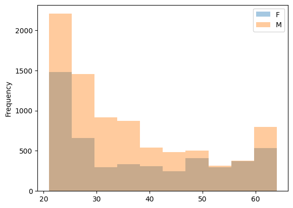

```python
df.groupby('gender')['age'].plot.hist(bins=10, alpha=0.4, legend=True)
```

```
gender
F    Axes(0.125,0.11;0.775x0.77)
M    Axes(0.125,0.11;0.775x0.77)
Name: weight_kg, dtype: object
```

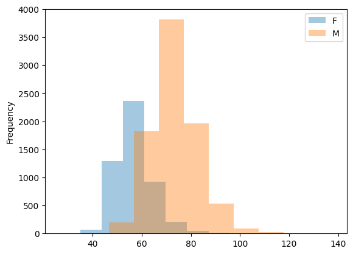

```python
df.groupby('gender')['weight_kg'].plot.hist(bins=10, alpha=0.4, legend=True)
```

```
gender
F    Axes(0.125,0.11;0.775x0.77)
M    Axes(0.125,0.11;0.775x0.77)
Name: height_cm, dtype: object
```

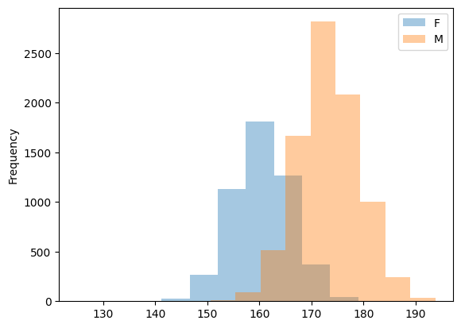

```python
df.groupby('gender')['height_cm'].plot.hist(bins=10, alpha=0.4, legend=True)
```

#### My Explanation

- **Age**: The age distribution for female is more average, while male are generally younger
- **Weight**:The weight for female is generally lighter than male
- **Height**: The height for male is generally higher than female

### Q5: 16 pt:

[Blood pressure](https://www.health.harvard.edu/heart-health/reading-the-new-blood-pressure-guidelines) is reported as two numbers: diastolic (the lower number) and systolic (the higher number). So, for example, if a person has a diastolic measurement of 80 and a systolic measurement of 120, the person's blood pressure would be reported as 120/80.

Blood pressure measurements fall into several categories:

Normal blood pressure. Your blood pressure is normal if it's below 120/80 mm Hg.

Elevated blood pressure. Elevated blood pressure is a systolic pressure ranging from 120 to 129 mm Hg and a diastolic pressure below (not above) 80 mm Hg. Elevated blood pressure may also be called prehypertension.

Stage 1 hypertension. Stage 1 hypertension is a systolic pressure ranging from 130 to 139 mm Hg or a diastolic pressure ranging from 80 to 89 mm Hg.

Stage 2 hypertension. More-severe hypertension, stage 2 hypertension is a systolic pressure of 140 mm Hg or higher or a diastolic pressure of 90 mm Hg or higher.

Hypertensive crisis. A blood pressure measurement higher than 180/120 mm Hg is an emergency situation that requires urgent medical care.

a) Report the number of people in each of those categories.

b) The guidelines were recently changed: prior to 2017, the guidelines set the threshold at 140/90 mm Hg for people younger than age 65 and 150/80 mm Hg for those ages 65 and older to be diagnosed with hypertension. Create and implement analyses that allow you to demonstrate how the change in guidelines affects the categorization of people into the different categories. Make reasonable assumptions (and state them) about whether to use diastolic, systolic, both, or either of those measures when implementing your analysis. Note that the new guidelines offer more categories than the older guidelines.

#### Part a)

```python
print("Normal blood pressure:", len(df[(df['systolic'] < 120) & (df['diastolic'] < 80)]))
print("Elevated blood pressure (prehypertension):", len(df[(df['systolic'] >= 120) & (df['systolic'] <= 129) & (df['diastolic'] < 80)]))
print("Stage 1 hypertension:", len(df[((df['systolic'] >= 130) & (df['systolic'] <= 139)) | ((df['diastolic'] >= 80) & (df['diastolic'] <= 89))]))
print("Stage 2 hypertension:", len(df[(df['systolic'] >= 140) | ((df['diastolic'] >= 90))]))
print("Hypertensive crisis:", len(df[(df['systolic'] > 180) & (df['diastolic'] > 120)]))
```

```
Normal blood pressure: 2898
Elevated blood pressure (prehypertension): 2090
Stage 1 hypertension: 5936
Stage 2 hypertension: 4418
Hypertensive crisis: 1
```

#### My Explanation

The number of people in the following categories:

- Normal blood pressure: 2898, 21.6% of the total people
- Elevated blood pressure (prehypertension): 2090, 15.6% of the total people
- Stage 1 hypertension: 5936, 44.3% of the total people
- Stage 2 hypertension: 4418, 33.0% of the total people
- Hypertensive crisis: 1, less than 1% of the total people

*Note: When identifing the **'Hypertensive crisis'**, my understanding is that the both systolic and idastolic have to exceed 180/120 mm Hg.*

#### Part b)

```python
df_change=df.copy(deep=True)
df_change['before_2017']='normal'
df_change['after_2017']='normal'
df_change.loc[(df_change['age'] <= 30) & (df_change['systolic'] >= 140) & (df_change['diastolic'] >= 90), 'before_2017'] = 'hypertension'
df_change.loc[(df_change['age'] >= 65) & (df_change['systolic'] >= 150) & (df_change['diastolic'] >= 80), 'before_2017'] = 'hypertension'
df_change.loc[((df_change['systolic'] >= 130) & (df_change['systolic'] <= 139)) | ((df_change['diastolic'] >= 80) & (df_change['diastolic'] <= 89)), 'after_2017'] = 'hypertension'
df_change.loc[(df_change['systolic'] >= 140) | ((df_change['diastolic'] >= 90)), 'after_2017'] = 'hypertension'
```

```python
df_change.groupby(['before_2017', 'after_2017'])['before_2017'].value_counts()
```

```
before_2017   after_2017
hypertension  hypertension     468
normal        hypertension    7937
              normal          4988
Name: count, dtype: int64
```

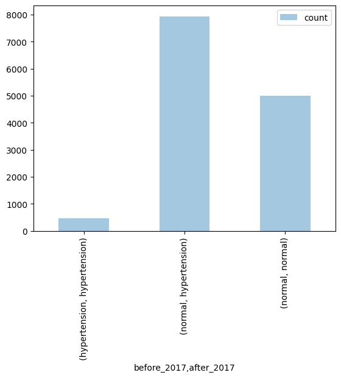

```python
df_change.groupby(['before_2017', 'after_2017'])['before_2017'].value_counts().plot.bar(alpha=0.4, legend=True)
```

#### My Explanation

- From the analysis, we can see that there are 468 people remain **'hypertension'** regardless of the guideline change, taking up 3.5%
- There are 7937 people change from **'normal'** into **'hypertension'**, taking up 59.3%
- There are 4988 people remain **'normal'**, taking up 37.2%
- No people change from **'hypertension'** to **'normal'**

**So generally, the new guideline seems to be more strict because it classify more people into hypertension**

### Q6: 10 pt:

Create a new variable "age_class" that is "early" if age < 40, "middle" if age is between 40 and 60 (inclusive) and "late" if age > 60. Report the mean and median number of sit-ups counts for each of those categories.

```python
# put your code here
df['age_class']='early'
df.loc[(df['age'] >= 40) & (df['age'] <= 60),'age_class']='middle'
df.loc[(df['age'] > 60),'age_class']='late'
```

```python
df.groupby('age_class')['sit-ups counts'].mean().round(1)
```

```
age_class
early     45.3
late      24.1
middle    31.8
Name: sit-ups counts, dtype: float64
```

```python
df.groupby('age_class')['sit-ups counts'].median()
```

```
age_class
early     47.0
late      25.0
middle    32.0
Name: sit-ups counts, dtype: float64
```

#### My Explanation

- The mean for early, middle and late are 45.3, 31.8 and 24.1 respectively
- The median for early, middle and late are 47, 32 and 25 respectively

From which we can see that

- With people getting older, they tend to do less sit-ups
- The average is a slightly smaller than the median, which means that more people tend to do less sit-ups

### Q7: 15 pt:

Calculate each person's Body Mass Index (BMI). With the metric system, the formula for BMI is weight in kilograms divided by height in meters squared. Since height is commonly measured in centimeters, an alternate calculation formula, dividing the weight in kilograms by the height in centimeters squared, and then multiplying the result by 10,000, can be used. (https://www.cdc.gov/nccdphp/dnpao/growthcharts/training/bmiage/page5_1.html)

Create two histograms of BMI: one for gender F and one for gender M. Describe similarites and differences of the two histograms.

```python
# put your code here
df['bmi']=df['weight_kg']/(df['height_cm']/100)**2
```

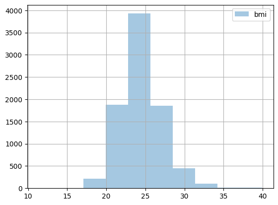

```python
df[df['gender']=='M'].bmi.hist(bins=10, alpha=0.4, legend=True)
```

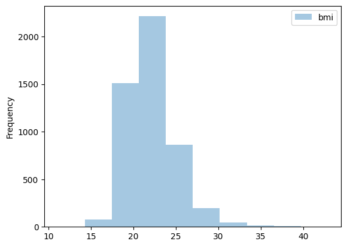

```python
df[df['gender']=='F'].bmi.plot.hist(bins=10, alpha=0.4, legend=True)
```

```
gender
F    Axes(0.125,0.11;0.775x0.77)
M    Axes(0.125,0.11;0.775x0.77)
Name: bmi, dtype: object
```

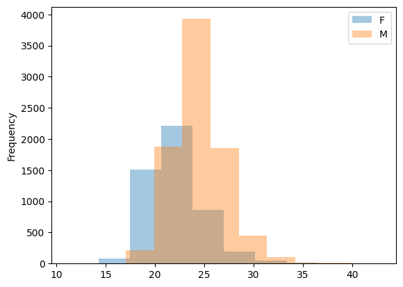

```python
df.groupby('gender').bmi.plot.hist(bins=10, alpha=0.4, legend=True)
```

#### My Explanation

To compare bmi of male and female, put the two histograms into one figure

**Similarities**:

### Q8: 12 pt:

Compare the mean values of height, weight, body fat %, grip force, sit and bend forward, and sit-ups count for gender F vs. gender M. You should use both quantitative and visual methods in your work.

```python
# put your code here
df.groupby('gender')[['height_cm', 'weight_kg', 'body fat_%', 'gripForce', 'sit and bend forward_cm', 'sit-ups counts' ]].mean().round(1)
```

| gender | height_cm | weight_kg | body fat_% | gripForce | sit and bend forward_cm | sit-ups counts |
| --- | --- | --- | --- | --- | --- | --- |
| F | 160.5 | 56.9 | 28.5 | 25.8 | 18.8 | 30.9 |
| M | 173.3 | 73.6 | 20.2 | 43.4 | 13.1 | 44.9 |

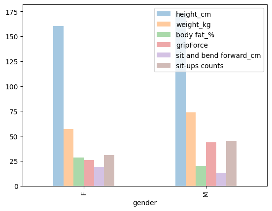

```python
df.groupby('gender')[['height_cm', 'weight_kg', 'body fat_%', 'gripForce', 'sit and bend forward_cm', 'sit-ups counts' ]].mean().plot.bar(alpha=0.4, legend=True)
```

#### My Explanation

By applying both quantitative and visual methods, we can find that male overwhelm female in almost all fields except for **body fat** and **sit and bend forward**. It may indicate that female are less likely to gain weight or they pay more attention to their body fat. Also, it can be inferred that the female have better body flexibility.

### Q9: 18 pt:

Take a look at gripForce (a measure of strength), "sit and bend forward" (a measure of flexibility), and "sit-ups count" (a measures of strength and endurance of the abdominals and hip-flexor muscles). For each of those measures, calculate their z-scores (i.e. subtract the mean of the variable from each observation, then divide by the standard deviation of that score). Create an overall fitness score by adding the z-scores for each of those variables together, then use `pd.qcut()` (not `pd.cut()`) to assign them to five categories ranging from lowest score to highest score.

a) Report the number of individuals in each of the resulting categories.

b) Comment on the degree to which your categories correspond to the `class` column.

#### Part a)

```python
# put your code here
df[['gripForce_z', 'sit and bend forward_cm_z', 'sit-ups counts_z']] = (df[['gripForce', 'sit and bend forward_cm', 'sit-ups counts']] - df[['gripForce', 'sit and bend forward_cm', 'sit-ups counts']].mean())/df[['gripForce', 'sit and bend forward_cm', 'sit-ups counts']].std()
df[['gripForce_z', 'sit and bend forward_cm_z', 'sit-ups counts_z']]
```

|  | gripForce_z | sit and bend forward_cm_z | sit-ups counts_z |
| --- | --- | --- | --- |
| 0 | 1.688127 | 0.377303 | 1.416909 |
| 1 | -0.053071 | 0.128979 | 0.926599 |
| 2 | 0.737527 | -0.379495 | 0.646422 |
| 3 | 0.417523 | -0.001096 | 0.926599 |
| 4 | 0.615172 | 1.406076 | 0.366245 |
| ... | ... | ... | ... |
| 13388 | -0.109543 | 0.259053 | 0.506334 |
| 13389 | -0.373076 | -1.668418 | 0.576378 |
| 13390 | 2.497549 | 0.140804 | 0.366245 |
| 13391 | -1.662504 | -0.710595 | -2.785744 |
| 13392 | -0.100131 | -0.958919 | 0.786511 |

13393 rows × 3 columns

```python
df['overall_fitness_score'] = df['gripForce_z'] + df['sit and bend forward_cm_z'] + df['sit-ups counts_z']
df['overall_fitness_score']
```

```
0        3.482339
1        1.002506
2        1.004454
3        1.343026
4        2.387494
           ...
13388    0.655845
13389   -1.465115
13390    3.004599
13391   -5.158842
13392   -0.272539
Name: overall_fitness_score, Length: 13393, dtype: float64
```

```python
pd.qcut(df['overall_fitness_score'], q=5)
```

```
0                     (1.773, 24.469]
1                      (0.642, 1.773]
2                      (0.642, 1.773]
3                      (0.642, 1.773]
4                     (1.773, 24.469]
                     ...
13388                  (0.642, 1.773]
13389                (-1.738, -0.388]
13390                 (1.773, 24.469]
13391    (-8.549999999999999, -1.738]
13392                 (-0.388, 0.642]
Name: overall_fitness_score, Length: 13393, dtype: category
Categories (5, interval[float64, right]): [(-8.549999999999999, -1.738] < (-1.738, -0.388] < (-0.388, 0.642] < (0.642, 1.773] < (1.773, 24.469]]
```

```python
df['overall_category'] = pd.qcut(df['overall_fitness_score'], q=5, labels=['very poor', 'poor', 'fair', 'good', 'very good'])
```

```python
df[['overall_fitness_score','overall_category']]
```

|  | overall_fitness_score | overall_category |
| --- | --- | --- |
| 0 | 3.482339 | very good |
| 1 | 1.002506 | good |
| 2 | 1.004454 | good |
| 3 | 1.343026 | good |
| 4 | 2.387494 | very good |
| ... | ... | ... |
| 13388 | 0.655845 | good |
| 13389 | -1.465115 | poor |
| 13390 | 3.004599 | very good |
| 13391 | -5.158842 | very poor |
| 13392 | -0.272539 | fair |

13393 rows × 2 columns

```python
df.groupby('overall_category').size()
# df['overall_category'].value_counts()
```

```
overall_category
very poor    2679
poor         2678
fair         2679
good         2678
very good    2679
dtype: int64
```

#### My Explanation

We seperate the individual into 5 catugories as the following:

- very poor: [-8.549999999999999, -1.738], 2679 people
- poor: (-1.738, -0.388], 2678 people
- fair: (-0.388, 0.642], 2679 people
- good: (0.642, 1.773], 2678 people
- very good: (1.773, 24.469], 2679 people

#### Part b)

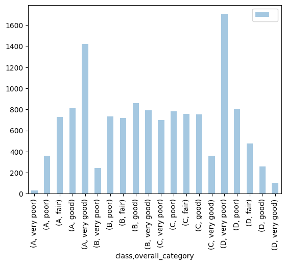

```python
df.groupby(['class', 'overall_category']).size().plot.bar(alpha=0.4, legend=True)
```

#### My Explanation

The original **class** 'A' and 'D' performs well since 'very good' and 'very poor' are high respectively. However, since we have 2 remaining **class** 'B' and 'C', and three new intervals 'poor', 'fair', and 'good', they may not match well. The next step should be change the new categories into 4 categories.

### IMPORTANT: Ensure your complete notebook runs without errors from top to bottom (check by using "Run All").

## Please submit your completed notebook in .IPYNB and .HTML formats via Canvas